# Predictive analysis of customer behaviour for retention

- **Business Understanding**
  - Background
  - Problem Statement
  - Objectives
- **Data Understanding**
  - Data Capture and explanation
  - Data Exploration
- **Data Preparation**
  - Data Preparation
  - Feature Engineering
- **Modeling and pipelines creation**
  - Machine Learning Models
  - Hyperparameter tuning
  - Ensemble Learning
- **Model Evaluation and Selection**
  - Evaluation metrics
  - Results interpretation
  - Model Selection analysis
- **Conclusion**
  - Results analysis
  - Recommendations

## Business Understanding

### Background

The global telecommunications industry is a vast and complex network of companies and technologies that enable communication across the globe.They had a value of $1.4 trillion in 2019. With the transition to 5G services set to take the world by storm in the next few years, the industry is expected to grow to even greater heights. It’s an exciting time for telecoms! 5G connectivity has the potential to transform the world we live in by making us more connected and our devices more intelligent.

However, for many telecom companies, more advancement and innovation means more competition for customers. It’s no secret that consumers in 2023 have exceedingly high expectations and an abundance of choices. While companies have always had to compete with customers telling their friends and family about their experiences, this is taken to another level in the digital age. Consumers take to the internet to leave reviews (both good and bad) and share their experiences on social media. We live in a fast-paced world where you can get your shopping delivered within 24 hours, get entertainment on demand, and, well, anything on demand. Consumers expect the same from every company they buy from, and telecoms is no exception.

77% of all consumers retract their loyalty more quickly than they did three years ago. This means customer retention in the telecom industry is harder to achieve than ever before.

As the industry has reached a saturation point, new customer acquisitions can’t make up for the lost ones. This further motivates ISPs and telcos to implement retention strategies. Research shows that even a 5% increase in a company’s retention rate can increase profits by 25% to 95%.

We’re going to look at how to increase customer retention in the telecom industry by analyzing the sample dataset provided by IBM. The features in the dataset, explained below, signify the customer behavior for an imaginary telecommunications company. Dataset: [Telco Customer Churn](https://www.kaggle.com/datasets/blastchar/telco-customer-churn)

#### Data Dictionary

| S.No | Attribute | Description |
| --- | --- | --- |
| 1 | customerID | Customer identification in the company |
| 2 | gender | Whether the customer is a male or a female |
| 3 | SeniorCitizen | Whether the customer is a senior citizen or not [1, 0] |
| 4 | Partner | Whether the customer has a partner or not (Yes, No) |
| 5 | Dependents | Whether the customer has dependents or not (Yes, No) |
| 6 | tenure | Number of months the customer has stayed with the company |
| 7 | PhoneService | Whether the customer has a phone service or not (Yes, No) |
| 8 | MultipleLines | Whether the customer has multiple lines or not (Yes, No, No phone service) |
| 9 | InternetService | Customer’s internet service provider (DSL, Fiber optic, No) |
| 10 | OnlineSecurity | Whether the customer has online security or not (Yes, No, No internet service) |
| 11 | OnlineBackup | Whether the customer has online backup or not (Yes, No, No internet service) |
| 12 | DeviceProtection | Whether the customer has device protection or not (Yes, No, No internet service) |
| 13 | TechSupport | Whether the customer has tech support or not (Yes, No, No internet service) |
| 14 | StreamingTV | Whether the customer has streaming TV or not (Yes, No, No internet service) |
| 15 | StreamingMovies | Whether the customer has streaming movies or not (Yes, No, No internet service) |
| 16 | Contract | The contract term of the customer (Month-to-month, One year, Two year) |
| 17 | PaperlessBilling | Whether the customer has paperless billing or not (Yes, No) |
| 18 | PaymentMethod | The customer’s payment method (Electronic check, Mailed check, Bank transfer (automatic), Credit card (automatic)) |
| 19 | MonthlyCharges | The amount charged to the customer monthly |
| 20 | TotalCharges | The total amount charged to the customer |
| 21 | Churn | Whether the customer churned or not (Yes or No) |

### Problem Statement

Using the given dataset, build a customer churn rate prediction model for the telecommunication company which will help the company to formulate customer retention policies and services.

### Objective

Develop a machine learning model, which will predict if a customer will stay or leave the telcoommunications company.

## Data Understanding

```python
# Install imblearn (if not installed already) for handling imbalance classification class
#!pip install imblearn
```

#### Libraries

```python
# Data processing, CSV file I/O
import pandas as pd

# Linear Algebra
import numpy as np

# Visualization
import seaborn as sns
import matplotlib.pyplot as plt
%matplotlib inline
import plotly.express as px

# Libraries for ML

# Standardization
from sklearn.preprocessing import StandardScaler

from sklearn.linear_model import LogisticRegression
from sklearn.model_selection import train_test_split, GridSearchCV
from sklearn.metrics import accuracy_score ,confusion_matrix,classification_report, plot_roc_curve,roc_curve
from sklearn.svm import SVC
from sklearn.tree import DecisionTreeClassifier
from sklearn.model_selection import cross_val_score
from imblearn.over_sampling import SMOTE
from sklearn.model_selection import StratifiedKFold
from collections import Counter

# Import warnings
import warnings
# Filter warnings
warnings.filterwarnings('ignore')

from sklearn.cluster import KMeans
from sklearn.metrics import silhouette_samples, silhouette_score
from sklearn import metrics
```

### Data Capture and explanation

```python
# Using read_csv function present in pandas library to import our data i.e telco-customer-churn.csv
data = pd.read_csv('telco-customer-churn.csv')
```

```python
# Checking the first 5 rows of the dataframe

data.head()
```

|  | customerID | gender | SeniorCitizen | Partner | Dependents | tenure | PhoneService | MultipleLines | InternetService | OnlineSecurity | ... | DeviceProtection | TechSupport | StreamingTV | StreamingMovies | Contract | PaperlessBilling | PaymentMethod | MonthlyCharges | TotalCharges | Churn |
| --- | --- | --- | --- | --- | --- | --- | --- | --- | --- | --- | --- | --- | --- | --- | --- | --- | --- | --- | --- | --- | --- |
| 0 | 7590-VHVEG | Female | 0 | Yes | No | 1 | No | No phone service | DSL | No | ... | No | No | No | No | Month-to-month | Yes | Electronic check | 29.85 | 29.85 | No |
| 1 | 5575-GNVDE | Male | 0 | No | No | 34 | Yes | No | DSL | Yes | ... | Yes | No | No | No | One year | No | Mailed check | 56.95 | 1889.5 | No |
| 2 | 3668-QPYBK | Male | 0 | No | No | 2 | Yes | No | DSL | Yes | ... | No | No | No | No | Month-to-month | Yes | Mailed check | 53.85 | 108.15 | Yes |
| 3 | 7795-CFOCW | Male | 0 | No | No | 45 | No | No phone service | DSL | Yes | ... | Yes | Yes | No | No | One year | No | Bank transfer (automatic) | 42.30 | 1840.75 | No |
| 4 | 9237-HQITU | Female | 0 | No | No | 2 | Yes | No | Fiber optic | No | ... | No | No | No | No | Month-to-month | Yes | Electronic check | 70.70 | 151.65 | Yes |

5 rows × 21 columns

```python
# Checking the last 5 rows of the dataframe

data.tail()
```

|  | customerID | gender | SeniorCitizen | Partner | Dependents | tenure | PhoneService | MultipleLines | InternetService | OnlineSecurity | ... | DeviceProtection | TechSupport | StreamingTV | StreamingMovies | Contract | PaperlessBilling | PaymentMethod | MonthlyCharges | TotalCharges | Churn |
| --- | --- | --- | --- | --- | --- | --- | --- | --- | --- | --- | --- | --- | --- | --- | --- | --- | --- | --- | --- | --- | --- |
| 7038 | 6840-RESVB | Male | 0 | Yes | Yes | 24 | Yes | Yes | DSL | Yes | ... | Yes | Yes | Yes | Yes | One year | Yes | Mailed check | 84.80 | 1990.5 | No |
| 7039 | 2234-XADUH | Female | 0 | Yes | Yes | 72 | Yes | Yes | Fiber optic | No | ... | Yes | No | Yes | Yes | One year | Yes | Credit card (automatic) | 103.20 | 7362.9 | No |
| 7040 | 4801-JZAZL | Female | 0 | Yes | Yes | 11 | No | No phone service | DSL | Yes | ... | No | No | No | No | Month-to-month | Yes | Electronic check | 29.60 | 346.45 | No |
| 7041 | 8361-LTMKD | Male | 1 | Yes | No | 4 | Yes | Yes | Fiber optic | No | ... | No | No | No | No | Month-to-month | Yes | Mailed check | 74.40 | 306.6 | Yes |
| 7042 | 3186-AJIEK | Male | 0 | No | No | 66 | Yes | No | Fiber optic | Yes | ... | Yes | Yes | Yes | Yes | Two year | Yes | Bank transfer (automatic) | 105.65 | 6844.5 | No |

5 rows × 21 columns

```python
# Checking the shape of the data

data.shape
```

```
(7043, 21)
```

**Observation:** The dataset contains 7043 records and each record has 21 features including the target variable called "Churn"

### Data Exploration

#### Data types of the features

```python
data.dtypes
```

```
customerID           object
gender               object
SeniorCitizen         int64
Partner              object
Dependents           object
tenure                int64
PhoneService         object
MultipleLines        object
InternetService      object
OnlineSecurity       object
OnlineBackup         object
DeviceProtection     object
TechSupport          object
StreamingTV          object
StreamingMovies      object
Contract             object
PaperlessBilling     object
PaymentMethod        object
MonthlyCharges      float64
TotalCharges         object
Churn                object
dtype: object
```

**Observation:**

- The feature "TotalCharges" is an object data type, but it should be a numerical data type i.e. float64.
- There are a lot of "object" dtypes which needs to be converted into numerical values using one hot encoding for a better performing machine learning model.

#### Basic information about the dataset

```python
data.info()
```

```
<class 'pandas.core.frame.DataFrame'>
RangeIndex: 7043 entries, 0 to 7042
Data columns (total 21 columns):
 #   Column            Non-Null Count  Dtype
---  ------            --------------  -----
 0   customerID        7043 non-null   object
 1   gender            7043 non-null   object
 2   SeniorCitizen     7043 non-null   int64
 3   Partner           7043 non-null   object
 4   Dependents        7043 non-null   object
 5   tenure            7043 non-null   int64
 6   PhoneService      7043 non-null   object
 7   MultipleLines     7043 non-null   object
 8   InternetService   7043 non-null   object
 9   OnlineSecurity    7043 non-null   object
 10  OnlineBackup      7043 non-null   object
 11  DeviceProtection  7043 non-null   object
 12  TechSupport       7043 non-null   object
 13  StreamingTV       7043 non-null   object
 14  StreamingMovies   7043 non-null   object
 15  Contract          7043 non-null   object
 16  PaperlessBilling  7043 non-null   object
 17  PaymentMethod     7043 non-null   object
 18  MonthlyCharges    7043 non-null   float64
 19  TotalCharges      7043 non-null   object
 20  Churn             7043 non-null   object
dtypes: float64(1), int64(2), object(18)
memory usage: 1.1+ MB
```

**Observation:** There are no missing or null values in the dataset.

#### Confirm missing values of the dataset

```python
data.isnull().values.any()
```

```
False
```

```python
data.isnull().sum()
```

```
customerID          0
gender              0
SeniorCitizen       0
Partner             0
Dependents          0
tenure              0
PhoneService        0
MultipleLines       0
InternetService     0
OnlineSecurity      0
OnlineBackup        0
DeviceProtection    0
TechSupport         0
StreamingTV         0
StreamingMovies     0
Contract            0
PaperlessBilling    0
PaymentMethod       0
MonthlyCharges      0
TotalCharges        0
Churn               0
dtype: int64
```

**Observation:** Confirmed that there are no missing or any null values in the dataset

#### Basic statistics for both numerical and categorical features

```python
# Description of the data, showing numeric features

data.describe()
```

|  | SeniorCitizen | tenure | MonthlyCharges |
| --- | --- | --- | --- |
| count | 7043.000000 | 7043.000000 | 7043.000000 |
| mean | 0.162147 | 32.371149 | 64.761692 |
| std | 0.368612 | 24.559481 | 30.090047 |
| min | 0.000000 | 0.000000 | 18.250000 |
| 25% | 0.000000 | 9.000000 | 35.500000 |
| 50% | 0.000000 | 29.000000 | 70.350000 |
| 75% | 0.000000 | 55.000000 | 89.850000 |
| max | 1.000000 | 72.000000 | 118.750000 |

```python
# Showing categorical features

data.describe(include='object')
```

|  | customerID | gender | Partner | Dependents | PhoneService | MultipleLines | InternetService | OnlineSecurity | OnlineBackup | DeviceProtection | TechSupport | StreamingTV | StreamingMovies | Contract | PaperlessBilling | PaymentMethod | TotalCharges | Churn |
| --- | --- | --- | --- | --- | --- | --- | --- | --- | --- | --- | --- | --- | --- | --- | --- | --- | --- | --- |
| count | 7043 | 7043 | 7043 | 7043 | 7043 | 7043 | 7043 | 7043 | 7043 | 7043 | 7043 | 7043 | 7043 | 7043 | 7043 | 7043 | 7043 | 7043 |
| unique | 7043 | 2 | 2 | 2 | 2 | 3 | 3 | 3 | 3 | 3 | 3 | 3 | 3 | 3 | 2 | 4 | 6531 | 2 |
| top | 7590-VHVEG | Male | No | No | Yes | No | Fiber optic | No | No | No | No | No | No | Month-to-month | Yes | Electronic check |  | No |
| freq | 1 | 3555 | 3641 | 4933 | 6361 | 3390 | 3096 | 3498 | 3088 | 3095 | 3473 | 2810 | 2785 | 3875 | 4171 | 2365 | 11 | 5174 |

**Observation:**

- **"TotalCharges"** has **6531 unique values**, which clearly signifies the point of changing the data type of this feature to a numeric (float64) from an object data type.
- **"customerID"** have **7043 unique values**. This feature will not give any input to the ML models.

#### Checking unique values of each feature

```python
# Using the nunique function to calculate unique values

data.nunique()
```

```
customerID          7043
gender                 2
SeniorCitizen          2
Partner                2
Dependents             2
tenure                73
PhoneService           2
MultipleLines          3
InternetService        3
OnlineSecurity         3
OnlineBackup           3
DeviceProtection       3
TechSupport            3
StreamingTV            3
StreamingMovies        3
Contract               3
PaperlessBilling       2
PaymentMethod          4
MonthlyCharges      1585
TotalCharges        6531
Churn                  2
dtype: int64
```

#### Data Cleaning

```python
# Checking duplicate rows in the dataset

data[data.duplicated()]
```

|  | customerID | gender | SeniorCitizen | Partner | Dependents | tenure | PhoneService | MultipleLines | InternetService | OnlineSecurity | ... | DeviceProtection | TechSupport | StreamingTV | StreamingMovies | Contract | PaperlessBilling | PaymentMethod | MonthlyCharges | TotalCharges | Churn |
| --- | --- | --- | --- | --- | --- | --- | --- | --- | --- | --- | --- | --- | --- | --- | --- | --- | --- | --- | --- | --- | --- |

0 rows × 21 columns

**Observation:** There are no duplicate values in the dataset

```python
# Changing Data Type of "TotalCharges" from 'object' to 'float' as it is a continous numeric feature.

data["TotalCharges"] = pd.to_numeric(data["TotalCharges"], errors='coerce')
```

**Observation: TotalCharges** column was converted to float type.

```python
# Checking the data types after the change.

data.dtypes
```

```
customerID           object
gender               object
SeniorCitizen         int64
Partner              object
Dependents           object
tenure                int64
PhoneService         object
MultipleLines        object
InternetService      object
OnlineSecurity       object
OnlineBackup         object
DeviceProtection     object
TechSupport          object
StreamingTV          object
StreamingMovies      object
Contract             object
PaperlessBilling     object
PaymentMethod        object
MonthlyCharges      float64
TotalCharges        float64
Churn                object
dtype: object
```

```python
# Checking dataset information, to confirm missing/null values

data.info()
```

```
<class 'pandas.core.frame.DataFrame'>
RangeIndex: 7043 entries, 0 to 7042
Data columns (total 21 columns):
 #   Column            Non-Null Count  Dtype
---  ------            --------------  -----
 0   customerID        7043 non-null   object
 1   gender            7043 non-null   object
 2   SeniorCitizen     7043 non-null   int64
 3   Partner           7043 non-null   object
 4   Dependents        7043 non-null   object
 5   tenure            7043 non-null   int64
 6   PhoneService      7043 non-null   object
 7   MultipleLines     7043 non-null   object
 8   InternetService   7043 non-null   object
 9   OnlineSecurity    7043 non-null   object
 10  OnlineBackup      7043 non-null   object
 11  DeviceProtection  7043 non-null   object
 12  TechSupport       7043 non-null   object
 13  StreamingTV       7043 non-null   object
 14  StreamingMovies   7043 non-null   object
 15  Contract          7043 non-null   object
 16  PaperlessBilling  7043 non-null   object
 17  PaymentMethod     7043 non-null   object
 18  MonthlyCharges    7043 non-null   float64
 19  TotalCharges      7032 non-null   float64
 20  Churn             7043 non-null   object
dtypes: float64(2), int64(2), object(17)
memory usage: 1.1+ MB
```

**Observation:**

- **"TotalCharges"** feature now has missing values as the "errors=coerce" paramter in "to_numeric" function has converted string " " to NaN.
- A single space character is also considered as a string.

```python
# Checking null/missing values

data.isnull().values.any()
```

```
True
```

```python
data.isnull().sum()
```

```
customerID           0
gender               0
SeniorCitizen        0
Partner              0
Dependents           0
tenure               0
PhoneService         0
MultipleLines        0
InternetService      0
OnlineSecurity       0
OnlineBackup         0
DeviceProtection     0
TechSupport          0
StreamingTV          0
StreamingMovies      0
Contract             0
PaperlessBilling     0
PaymentMethod        0
MonthlyCharges       0
TotalCharges        11
Churn                0
dtype: int64
```

```python
data.isna().sum()
```

```
customerID           0
gender               0
SeniorCitizen        0
Partner              0
Dependents           0
tenure               0
PhoneService         0
MultipleLines        0
InternetService      0
OnlineSecurity       0
OnlineBackup         0
DeviceProtection     0
TechSupport          0
StreamingTV          0
StreamingMovies      0
Contract             0
PaperlessBilling     0
PaymentMethod        0
MonthlyCharges       0
TotalCharges        11
Churn                0
dtype: int64
```

**Observation:** There are 11 NaN values in the "TotalCharges" feature.

#### Data Imputation

```python
# Describing the numeric features again after data type change for the "TotalCharges" feature

data.describe()
```

|  | SeniorCitizen | tenure | MonthlyCharges | TotalCharges |
| --- | --- | --- | --- | --- |
| count | 7043.000000 | 7043.000000 | 7043.000000 | 7032.000000 |
| mean | 0.162147 | 32.371149 | 64.761692 | 2283.300441 |
| std | 0.368612 | 24.559481 | 30.090047 | 2266.771362 |
| min | 0.000000 | 0.000000 | 18.250000 | 18.800000 |
| 25% | 0.000000 | 9.000000 | 35.500000 | 401.450000 |
| 50% | 0.000000 | 29.000000 | 70.350000 | 1397.475000 |
| 75% | 0.000000 | 55.000000 | 89.850000 | 3794.737500 |
| max | 1.000000 | 72.000000 | 118.750000 | 8684.800000 |

```python
# Imputing the NaN values with the median of the feature "TotalCharges"

data['TotalCharges'] = data['TotalCharges'].fillna(data['TotalCharges'].median())
```

```python
# Checking null/missing values again after the imputation

data.isnull().values.any()
```

```
False
```

```python
data.isnull().sum()
```

```
customerID          0
gender              0
SeniorCitizen       0
Partner             0
Dependents          0
tenure              0
PhoneService        0
MultipleLines       0
InternetService     0
OnlineSecurity      0
OnlineBackup        0
DeviceProtection    0
TechSupport         0
StreamingTV         0
StreamingMovies     0
Contract            0
PaperlessBilling    0
PaymentMethod       0
MonthlyCharges      0
TotalCharges        0
Churn               0
dtype: int64
```

```python
data.isna().sum()
```

```
customerID          0
gender              0
SeniorCitizen       0
Partner             0
Dependents          0
tenure              0
PhoneService        0
MultipleLines       0
InternetService     0
OnlineSecurity      0
OnlineBackup        0
DeviceProtection    0
TechSupport         0
StreamingTV         0
StreamingMovies     0
Contract            0
PaperlessBilling    0
PaymentMethod       0
MonthlyCharges      0
TotalCharges        0
Churn               0
dtype: int64
```

```python
# Checking the statistics of the numeric features in dataset

data.describe()
```

|  | SeniorCitizen | tenure | MonthlyCharges | TotalCharges |
| --- | --- | --- | --- | --- |
| count | 7043.000000 | 7043.000000 | 7043.000000 | 7043.000000 |
| mean | 0.162147 | 32.371149 | 64.761692 | 2281.916928 |
| std | 0.368612 | 24.559481 | 30.090047 | 2265.270398 |
| min | 0.000000 | 0.000000 | 18.250000 | 18.800000 |
| 25% | 0.000000 | 9.000000 | 35.500000 | 402.225000 |
| 50% | 0.000000 | 29.000000 | 70.350000 | 1397.475000 |
| 75% | 0.000000 | 55.000000 | 89.850000 | 3786.600000 |
| max | 1.000000 | 72.000000 | 118.750000 | 8684.800000 |

```python
# Showing categorical features

data.describe(include='object')
```

|  | customerID | gender | Partner | Dependents | PhoneService | MultipleLines | InternetService | OnlineSecurity | OnlineBackup | DeviceProtection | TechSupport | StreamingTV | StreamingMovies | Contract | PaperlessBilling | PaymentMethod | Churn |
| --- | --- | --- | --- | --- | --- | --- | --- | --- | --- | --- | --- | --- | --- | --- | --- | --- | --- |
| count | 7043 | 7043 | 7043 | 7043 | 7043 | 7043 | 7043 | 7043 | 7043 | 7043 | 7043 | 7043 | 7043 | 7043 | 7043 | 7043 | 7043 |
| unique | 7043 | 2 | 2 | 2 | 2 | 3 | 3 | 3 | 3 | 3 | 3 | 3 | 3 | 3 | 2 | 4 | 2 |
| top | 7590-VHVEG | Male | No | No | Yes | No | Fiber optic | No | No | No | No | No | No | Month-to-month | Yes | Electronic check | No |
| freq | 1 | 3555 | 3641 | 4933 | 6361 | 3390 | 3096 | 3498 | 3088 | 3095 | 3473 | 2810 | 2785 | 3875 | 4171 | 2365 | 5174 |

#### Data Visualization

##### Visualising categorical features

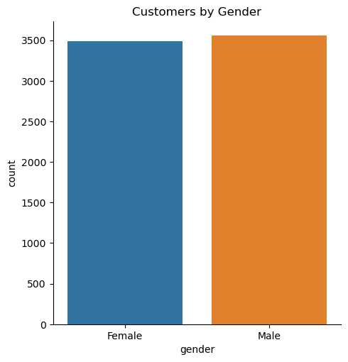

```python
# Gender count

sns.catplot(x="gender", kind="count", data=data)
plt.title("Customers by Gender")
plt.show()
```

**Observation:** The dataset is almost equally distributed between the two genders.

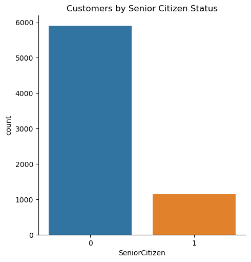

```python
# SeniorCitizen count

sns.catplot(x="SeniorCitizen", kind="count", data=data)
plt.title("Customers by Senior Citizen Status")
plt.show()
```

**Observation:** Senior citizens using the services are very less compared to the youth in the dataset.

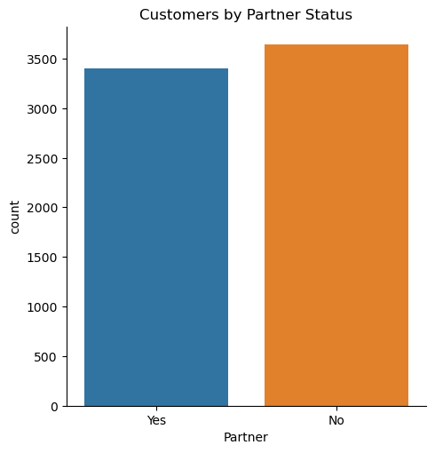

```python
# Partner count

sns.catplot(x="Partner", kind="count", data=data)
plt.title("Customers by Partner Status")
plt.show()
```

**Observation:** Both married and single customers are represented with similar count in the dataset.

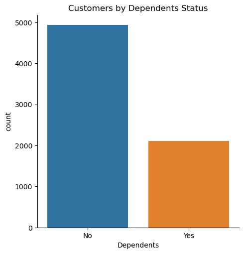

```python
# Dependents count

sns.catplot(x="Dependents", kind="count", data=data)
plt.title("Customers by Dependents Status")
plt.show()
```

**Observation:** The number of Dependents using the services are very less compared to others Independant customers.

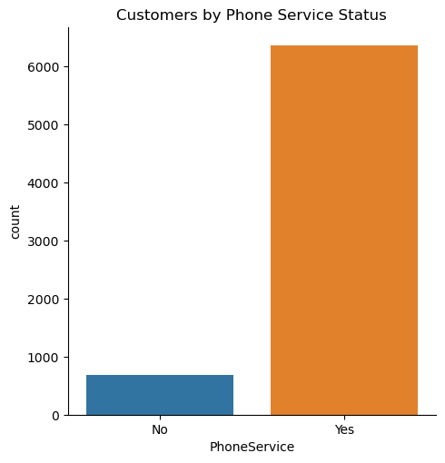

```python
# PhoneService count

sns.catplot(x="PhoneService", kind="count", data=data)
plt.title("Customers by Phone Service Status")
plt.show()
```

**Observation:** Most of the Customers primarily utilize the Phone service offering.

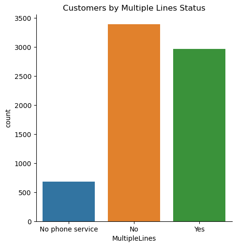

```python
# MultipleLines count

sns.catplot(x="MultipleLines", kind="count", data=data)
plt.title("Customers by Multiple Lines Status")
plt.show()
```

**Observation:** Mostly customers use only single line services and followed by the multiline services.

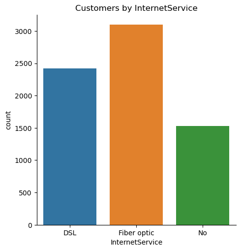

```python
# InternetService count

sns.catplot(x="InternetService", kind="count", data=data)
plt.title("Customers by InternetService")
plt.show()
```

**Observation:** Fibre Optic service is the highly used Internet Service by the Customers.

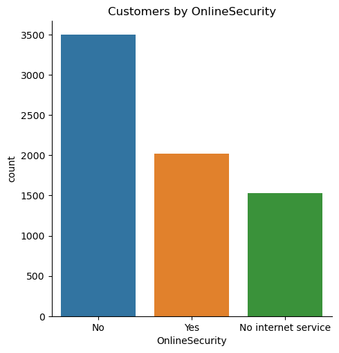

```python
# OnlineSecurity count

sns.catplot(x="OnlineSecurity", kind="count", data=data)
plt.title("Customers by OnlineSecurity")
plt.show()
```

**Observation:** Customers mostly don't have the Online Security Service.

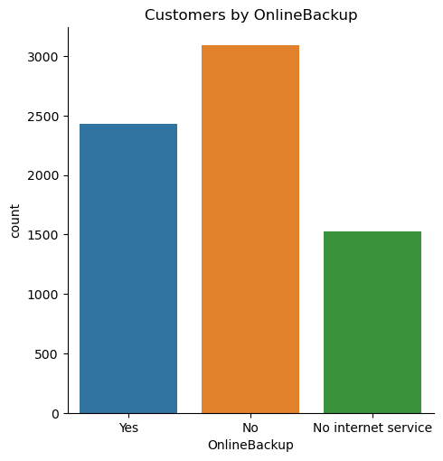

```python
# OnlineBackup count

sns.catplot(x="OnlineBackup", kind="count", data=data)
plt.title("Customers by OnlineBackup")
plt.show()
```

**Observation:** Most customers don't have the OnlineBackup Service.

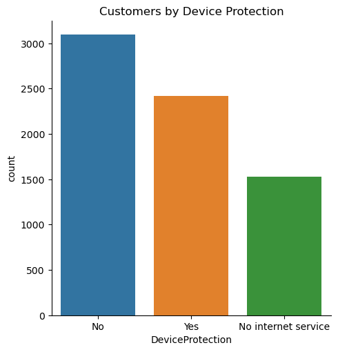

```python
# DeviceProtection count

sns.catplot(x="DeviceProtection", kind="count", data=data)
plt.title("Customers by Device Protection")
plt.show()
```

**Observation:** Most customers don't have the Device Protection Service.

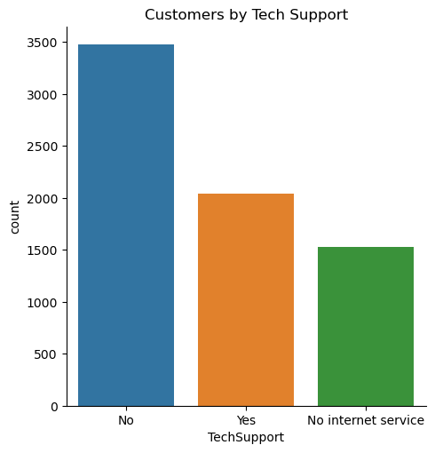

```python
# TechSupport count

sns.catplot(x="TechSupport", kind="count", data=data)
plt.title("Customers by Tech Support")
plt.show()
```

**Observation:** Most customers don't have the Tech Support Service.

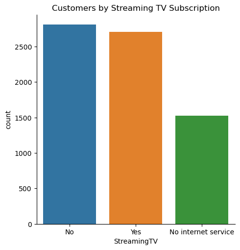

```python
# streamingTV count

sns.catplot(x="StreamingTV", kind="count", data=data)
plt.title("Customers by Streaming TV Subscription")
plt.show()
```

**Observation:** Customers are distributed on the streaming TV subscription.

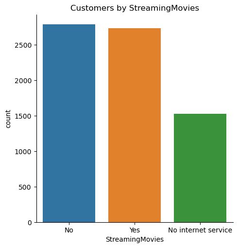

```python
# StreamingMovies count

sns.catplot(x="StreamingMovies", kind="count", data=data)
plt.title("Customers by StreamingMovies")
plt.show()
```

**Observation:** Customers are distributed on the streamingMovies service.

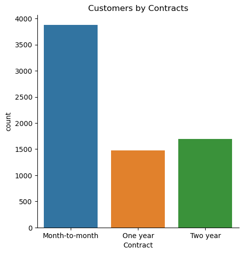

```python
# Contract count

sns.catplot(x="Contract", kind="count", data=data)
plt.title('Customers by Contracts')
plt.show()
```

**Observation:** Maximum customers stay in the Month to Month contract, which could be a big driving factor for the churn rate.

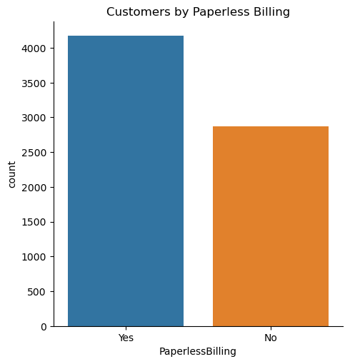

```python
# PaperlessBilling count

sns.catplot(x="PaperlessBilling", kind="count", data=data)
plt.title("Customers by Paperless Billing")
plt.show()
```

**Observation:** Customers majorly chose Paperless Billing for their Service.

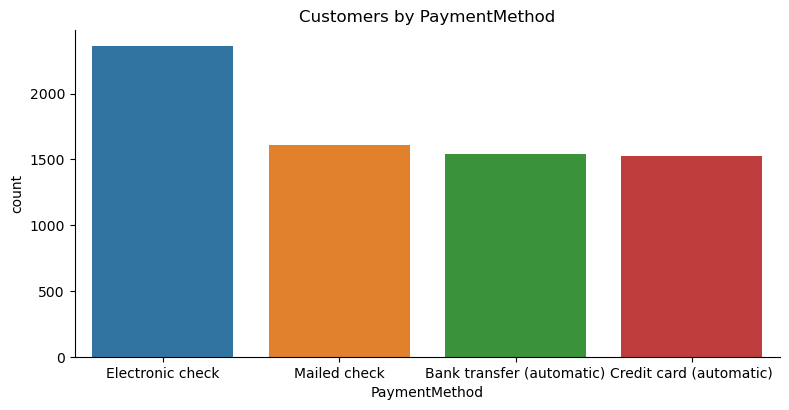

```python
# PaymentMethod count

sns.catplot(x="PaymentMethod", kind="count", data=data, height=4, aspect=2)
plt.title("Customers by PaymentMethod")
plt.show()
```

**Observation:** Customers mostly use the Electronic check Payment method to pay the bills.

##### Visualising numerical features

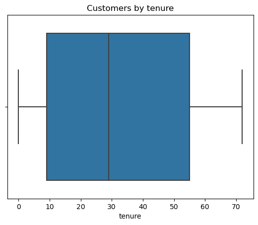

```python
# tenure

sns.boxplot(x=data["tenure"])
plt.title("Customers by tenure")
plt.show()
```

**Observation:** No outliers is being identified in the box plot for the "tenure" Feature.

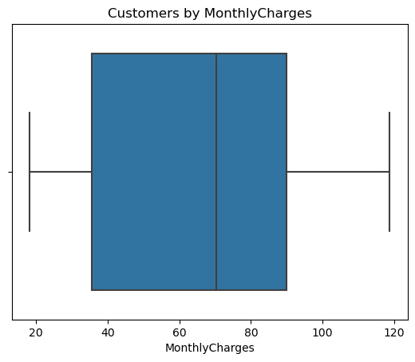

```python
# MonthlyCharges

sns.boxplot(x=data["MonthlyCharges"])
plt.title("Customers by MonthlyCharges")
plt.show()
```

**Observation:** No outliers is being identified in the box plot for the MonthlyCharges Feature.

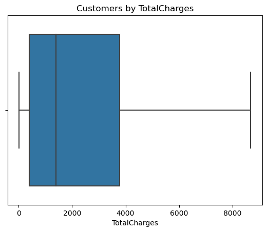

```python
# TotalCharges

sns.boxplot(x=data["TotalCharges"])
plt.title("Customers by TotalCharges")
plt.show()
```

**Observation:** No outliers is being identified in the box plot for the Total Charges Feature.

#### Checking for Imbalance class

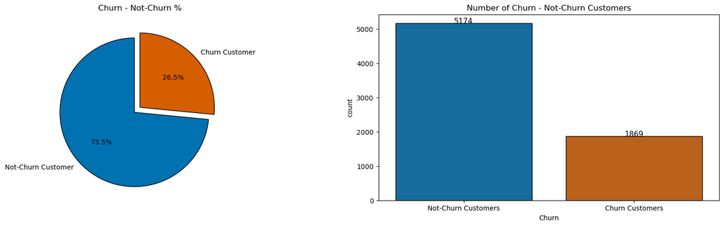

```python
# Checking for Imbalance class

l = list(data['Churn'].value_counts())
circle = [l[0] / sum(l) * 100,l[1] / sum(l) * 100]
blue = '#0072B2'
orange = '#D55E00'

colors = [blue, orange]
fig = plt.subplots(nrows = 1,ncols = 2,figsize = (20,5))
plt.subplot(1,2,1)
plt.pie(circle,labels = ['Not-Churn Customer','Churn Customer'],autopct = '%1.1f%%',startangle = 90,explode = (0.1,0),colors = colors,
       wedgeprops = {'edgecolor' : 'black','linewidth': 1,'antialiased' : True})
plt.title('Churn - Not-Churn %');

plt.subplot(1,2,2)
ax = sns.countplot('Churn',data = data,palette = colors,edgecolor = 'black')
for rect in ax.patches:
    ax.text(rect.get_x() + rect.get_width() / 2, rect.get_height() + 2, rect.get_height(), horizontalalignment='center', fontsize = 11)
ax.set_xticklabels(['Not-Churn Customers','Churn Customers'])

plt.title('Number of Churn - Not-Churn Customers');
plt.show()
```

**Observation:**

- **Target Label is Imbalanced**, where the Not-Churn Customers contribute 73.5% and Churn cutomers only contribute 26.5%.
- The Imbalanced data will be handled by the help of **SMOTE and stratified methods** for the various machine learning models.

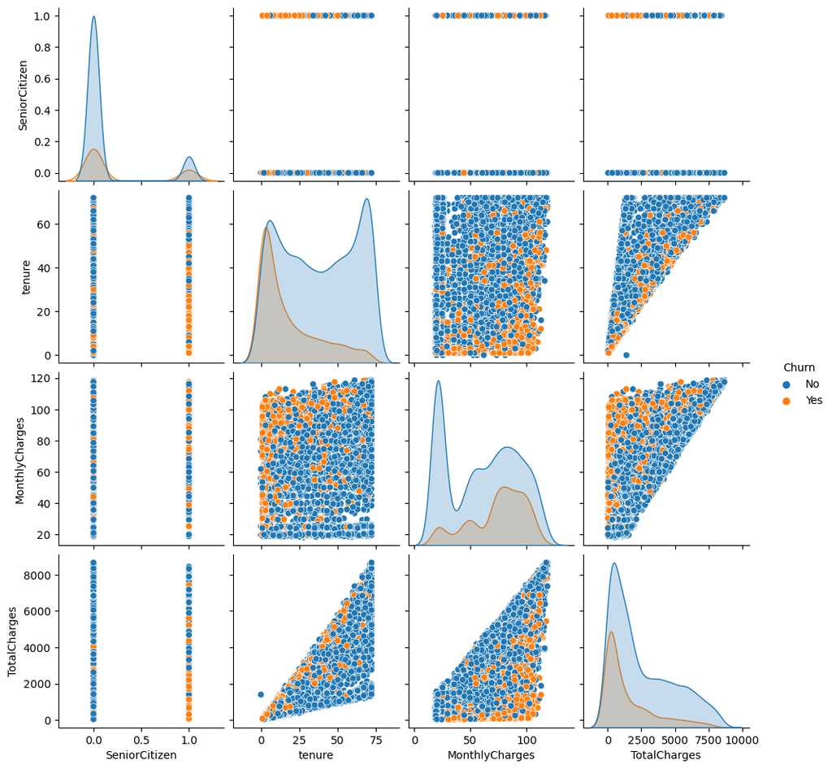

```python
# Further analysis with pairplot to show the distrubition of each numerical features against the target variable

sns.pairplot(data,hue='Churn')
plt.show()
```

#### K-Means Cluster (Unsupervised Machine Learning Model)

We are going to check what happens if we use K-Means Cluster Model which is an unsupervised ML Model in our dataset

```python
# Import kmeans model from SciKit Learn Library
from sklearn.cluster import KMeans
```

```python
# Take a version of our dataframe by taking a copy of it
data_kmc = data.copy()
```

```python
data_kmc.head()
```

|  | customerID | gender | SeniorCitizen | Partner | Dependents | tenure | PhoneService | MultipleLines | InternetService | OnlineSecurity | ... | DeviceProtection | TechSupport | StreamingTV | StreamingMovies | Contract | PaperlessBilling | PaymentMethod | MonthlyCharges | TotalCharges | Churn |
| --- | --- | --- | --- | --- | --- | --- | --- | --- | --- | --- | --- | --- | --- | --- | --- | --- | --- | --- | --- | --- | --- |
| 0 | 7590-VHVEG | Female | 0 | Yes | No | 1 | No | No phone service | DSL | No | ... | No | No | No | No | Month-to-month | Yes | Electronic check | 29.85 | 29.85 | No |
| 1 | 5575-GNVDE | Male | 0 | No | No | 34 | Yes | No | DSL | Yes | ... | Yes | No | No | No | One year | No | Mailed check | 56.95 | 1889.50 | No |
| 2 | 3668-QPYBK | Male | 0 | No | No | 2 | Yes | No | DSL | Yes | ... | No | No | No | No | Month-to-month | Yes | Mailed check | 53.85 | 108.15 | Yes |
| 3 | 7795-CFOCW | Male | 0 | No | No | 45 | No | No phone service | DSL | Yes | ... | Yes | Yes | No | No | One year | No | Bank transfer (automatic) | 42.30 | 1840.75 | No |
| 4 | 9237-HQITU | Female | 0 | No | No | 2 | Yes | No | Fiber optic | No | ... | No | No | No | No | Month-to-month | Yes | Electronic check | 70.70 | 151.65 | Yes |

5 rows × 21 columns

```python
# Initializing an instance of KMeans Data model with 3 clusters and random seed set to 123
k_means = KMeans(n_clusters=3, random_state = 123)
```

*Note:* *We are choosing 3 clusters just to check the result and we will use Elbow Method and Silhoutte Measure to find the most appropriate value of 'K'*

```python
# Fitting our model (kmeansmodel) to our dataset using the fit method
km_model = k_means.fit(data_kmc[['tenure', 'MonthlyCharges', 'TotalCharges']])
```

```python
# Return the final cluster centers for the fitted KMeans model
km_model.cluster_centers_
```

```
array([[  18.17194245,   49.74381295,  687.77107314],
       [  64.36428571,   97.91813492, 6291.77134921],
       [  44.08803472,   77.68632982, 3270.86401116]])
```

```python
# Return the cluster labels assigned by the KMeans model to each data point fit data
km_model.labels_
```

```
array([0, 0, 0, ..., 0, 0, 1])
```

**Observation:**  
Since we can not see our cluster lables clearly using 'km*model.labels*', so we will create a feature in our dataset to check and view the labels

```python
# Create a feature 'Group' in our dataset 'datav2'
data_kmc['Group'] = km_model.labels_

# Checking our dataset
data_kmc.head()
```

|  | customerID | gender | SeniorCitizen | Partner | Dependents | tenure | PhoneService | MultipleLines | InternetService | OnlineSecurity | ... | TechSupport | StreamingTV | StreamingMovies | Contract | PaperlessBilling | PaymentMethod | MonthlyCharges | TotalCharges | Churn | Group |
| --- | --- | --- | --- | --- | --- | --- | --- | --- | --- | --- | --- | --- | --- | --- | --- | --- | --- | --- | --- | --- | --- |
| 0 | 7590-VHVEG | Female | 0 | Yes | No | 1 | No | No phone service | DSL | No | ... | No | No | No | Month-to-month | Yes | Electronic check | 29.85 | 29.85 | No | 0 |
| 1 | 5575-GNVDE | Male | 0 | No | No | 34 | Yes | No | DSL | Yes | ... | No | No | No | One year | No | Mailed check | 56.95 | 1889.50 | No | 0 |
| 2 | 3668-QPYBK | Male | 0 | No | No | 2 | Yes | No | DSL | Yes | ... | No | No | No | Month-to-month | Yes | Mailed check | 53.85 | 108.15 | Yes | 0 |
| 3 | 7795-CFOCW | Male | 0 | No | No | 45 | No | No phone service | DSL | Yes | ... | Yes | No | No | One year | No | Bank transfer (automatic) | 42.30 | 1840.75 | No | 0 |
| 4 | 9237-HQITU | Female | 0 | No | No | 2 | Yes | No | Fiber optic | No | ... | No | No | No | Month-to-month | Yes | Electronic check | 70.70 | 151.65 | Yes | 0 |

5 rows × 22 columns

```python
# Check how many observations belong to each cluster group in our dataset
data_kmc.Group.value_counts()
```

```
0    4172
2    1612
1    1259
Name: Group, dtype: int64
```

#### Elbow Method

```python
# Checking the inertia of our model for current k value which is 3
km_model.inertia_
```

```
3707094586.3420944
```

```python
# Create a list for clusters and scores to store the cluster groups and score for a range of 'k' using for loop
clusters = []
scores = []

for k in range(1,5):
    k_means = KMeans(n_clusters=k, random_state = 123)
    clusters.append(k)
    km_model = k_means.fit(data_kmc[['tenure', 'MonthlyCharges', 'TotalCharges']])
    score = km_model.inertia_
    scores.append(score)
```

```python
# Checking the cluster groups
clusters
```

```
[1, 2, 3, 4]
```

```python
# Checking the score
scores
```

```
[36146294160.38064, 7926703678.930506, 3707094586.342094, 2119061526.8403509]
```

```python
# Store the number of clusters and their respective WSS scores a dataframe 'wss'
wss  = pd.DataFrame({'Cluster': clusters, 'Score': scores})

# Checking our dataset
wss
```

|  | Cluster | Score |
| --- | --- | --- |
| 0 | 1 | 3.614629e+10 |
| 1 | 2 | 7.926704e+09 |
| 2 | 3 | 3.707095e+09 |
| 3 | 4 | 2.119062e+09 |

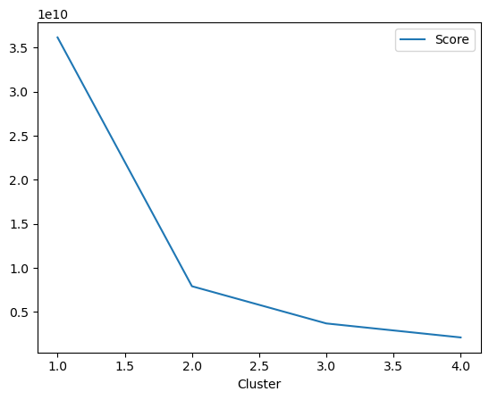

```python
# Plot an Elbow plot.
wss.plot(x='Cluster', y='Score')
```

**Observation:**

- The point where the elbow is bended, that would be the optimal point for k. In our case we can observe that 2 is the optimal value for k.
- Also our target feature is Churn or not-Churn, so there are only 2 classifications. Hence the optimal value for k would be 2

#### Silhouette Measure

The silhouette measure is a metric used to evaluate the quality of clustering results. It quantifies how similar a data point is to its own cluster compared to other clusters.  
The silhouette score ranges from -1 to 1, where a score of 1 indicates that a data point is well matched to its own cluster and poorly matched to neighboring clusters. A score of 0 indicates that a data point is on the boundary between two clusters, and negative scores indicate that a data point is better matched to a neighboring cluster than its own.  
We are using the **Silhouette Measure** to reconfirm that the value of k is 2 or not.

```python
# Import silhouette_score from SciKit Learn library
from sklearn.metrics import silhouette_score
```

```python
# Using for loop, calculate the silhouette score and store in s_clusters and s_scores

s_clusters = []
s_scores = []

for k in range(2,6):
    k_means = KMeans(n_clusters=k, random_state = 123)
    s_clusters.append(k)
    km_model = k_means.fit(data_kmc[['tenure', 'MonthlyCharges', 'TotalCharges']])
    score = silhouette_score(data_kmc[['tenure', 'MonthlyCharges', 'TotalCharges']], km_model.labels_)
    s_scores.append(score)
```

```python
# Checking the cluster groups
s_clusters
```

```
[2, 3, 4, 5]
```

```python
# Checking the score
s_scores
```

```
[0.703131602885925, 0.644201603824732, 0.6017524432572141, 0.5968442120640297]
```

```python
# Store the number of clusters and their respective silhouette scores in a dataframe
s_wss  = pd.DataFrame({'s_Cluster': s_clusters, 's_Score': s_scores})
s_wss
```

|  | s_Cluster | s_Score |
| --- | --- | --- |
| 0 | 2 | 0.703132 |
| 1 | 3 | 0.644202 |
| 2 | 4 | 0.601752 |
| 3 | 5 | 0.596844 |

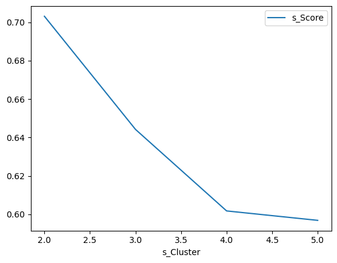

```python
# Plot the silhouette plot
s_wss.plot(x='s_Cluster', y='s_Score')
```

**Observation:**

- We can see that the closest Silhouette score to 1 is around 0.7, for which the k value is 2.
- **This again reconfirms that the number clusters for our output feature is 2 (k=2)**

**Reasons for not using K-Means Cluster Model:**

- Our Target feature is **"Churn Rate"** and Unsupervised ML Model will not be suitable for this case.
- Also the accuracy of using an unsupervised model for Binary Classification problem will be less compared to Supervised Models
- We have done K-Means Cluster Model for exploring with the dataset and analysing purpose.

### Data Preparation

There are 17 categorical columns which needs to be converted in numerical for a better machine learning model performance.

#### One-hot Encoding

```python
# Separating categorical and numerical columns

col = list(data.columns)
categorical_features = []
numerical_features = []
for i in col:
    if len(data[i].unique()) > 6:
        numerical_features.append(i)
    else:
        categorical_features.append(i)

print('Categorical Features :',*categorical_features)

print('Numerical Features :',*numerical_features)
```

```
Categorical Features : gender SeniorCitizen Partner Dependents PhoneService MultipleLines InternetService OnlineSecurity OnlineBackup DeviceProtection TechSupport StreamingTV StreamingMovies Contract PaperlessBilling PaymentMethod Churn
Numerical Features : customerID tenure MonthlyCharges TotalCharges
```

```python
# Display the distinct values for features

data.nunique()
```

```
customerID          7043
gender                 2
SeniorCitizen          2
Partner                2
Dependents             2
tenure                73
PhoneService           2
MultipleLines          3
InternetService        3
OnlineSecurity         3
OnlineBackup           3
DeviceProtection       3
TechSupport            3
StreamingTV            3
StreamingMovies        3
Contract               3
PaperlessBilling       2
PaymentMethod          4
MonthlyCharges      1585
TotalCharges        6531
Churn                  2
dtype: int64
```

```python
# Display value_counts() to determine the distinct values

for column in data.columns:
    value_counts = data[column].value_counts()
    print(f"Distinct Value Counts for column '{column}':\n{value_counts}\n\n\n")
```

```
Distinct Value Counts for column 'customerID':
7590-VHVEG    1
3791-LGQCY    1
6008-NAIXK    1
5956-YHHRX    1
5365-LLFYV    1
             ..
9796-MVYXX    1
2637-FKFSY    1
1552-AAGRX    1
4304-TSPVK    1
3186-AJIEK    1
Name: customerID, Length: 7043, dtype: int64



Distinct Value Counts for column 'gender':
Male      3555
Female    3488
Name: gender, dtype: int64



Distinct Value Counts for column 'SeniorCitizen':
0    5901
1    1142
Name: SeniorCitizen, dtype: int64



Distinct Value Counts for column 'Partner':
No     3641
Yes    3402
Name: Partner, dtype: int64



Distinct Value Counts for column 'Dependents':
No     4933
Yes    2110
```

[output cut: 136 more lines]

```
19.900       8
            ..
6849.400     1
692.350      1
130.150      1
3211.900     1
6844.500     1
Name: TotalCharges, Length: 6531, dtype: int64



Distinct Value Counts for column 'Churn':
No     5174
Yes    1869
Name: Churn, dtype: int64
```

```python
# Using the pandas for encoding the categorical features in our dataset

data = pd.get_dummies(data, columns=['gender', 'SeniorCitizen', 'Partner', 'Dependents', 'PhoneService', 'MultipleLines', 'InternetService', 'OnlineSecurity', 'OnlineBackup', 'DeviceProtection', 'TechSupport', 'StreamingTV', 'StreamingMovies', 'Contract', 'PaperlessBilling', 'PaymentMethod', 'Churn'],drop_first=True)
data.head()
```

|  | customerID | tenure | MonthlyCharges | TotalCharges | gender_Male | SeniorCitizen_1 | Partner_Yes | Dependents_Yes | PhoneService_Yes | MultipleLines_No phone service | ... | StreamingTV_Yes | StreamingMovies_No internet service | StreamingMovies_Yes | Contract_One year | Contract_Two year | PaperlessBilling_Yes | PaymentMethod_Credit card (automatic) | PaymentMethod_Electronic check | PaymentMethod_Mailed check | Churn_Yes |
| --- | --- | --- | --- | --- | --- | --- | --- | --- | --- | --- | --- | --- | --- | --- | --- | --- | --- | --- | --- | --- | --- |
| 0 | 7590-VHVEG | 1 | 29.85 | 29.85 | 0 | 0 | 1 | 0 | 0 | 1 | ... | 0 | 0 | 0 | 0 | 0 | 1 | 0 | 1 | 0 | 0 |
| 1 | 5575-GNVDE | 34 | 56.95 | 1889.50 | 1 | 0 | 0 | 0 | 1 | 0 | ... | 0 | 0 | 0 | 1 | 0 | 0 | 0 | 0 | 1 | 0 |
| 2 | 3668-QPYBK | 2 | 53.85 | 108.15 | 1 | 0 | 0 | 0 | 1 | 0 | ... | 0 | 0 | 0 | 0 | 0 | 1 | 0 | 0 | 1 | 1 |
| 3 | 7795-CFOCW | 45 | 42.30 | 1840.75 | 1 | 0 | 0 | 0 | 0 | 1 | ... | 0 | 0 | 0 | 1 | 0 | 0 | 0 | 0 | 0 | 0 |
| 4 | 9237-HQITU | 2 | 70.70 | 151.65 | 0 | 0 | 0 | 0 | 1 | 0 | ... | 0 | 0 | 0 | 0 | 0 | 1 | 0 | 1 | 0 | 1 |

5 rows × 32 columns

**Observation:** Category features are being Encoded.

```python
# Checking shape after encoding

data.shape
```

```
(7043, 32)
```

```python
data.info()
```

```
<class 'pandas.core.frame.DataFrame'>
RangeIndex: 7043 entries, 0 to 7042
Data columns (total 32 columns):
 #   Column                                 Non-Null Count  Dtype
---  ------                                 --------------  -----
 0   customerID                             7043 non-null   object
 1   tenure                                 7043 non-null   int64
 2   MonthlyCharges                         7043 non-null   float64
 3   TotalCharges                           7043 non-null   float64
 4   gender_Male                            7043 non-null   uint8
 5   SeniorCitizen_1                        7043 non-null   uint8
 6   Partner_Yes                            7043 non-null   uint8
 7   Dependents_Yes                         7043 non-null   uint8
 8   PhoneService_Yes                       7043 non-null   uint8
 9   MultipleLines_No phone service         7043 non-null   uint8
```

[output cut: 24 more lines]

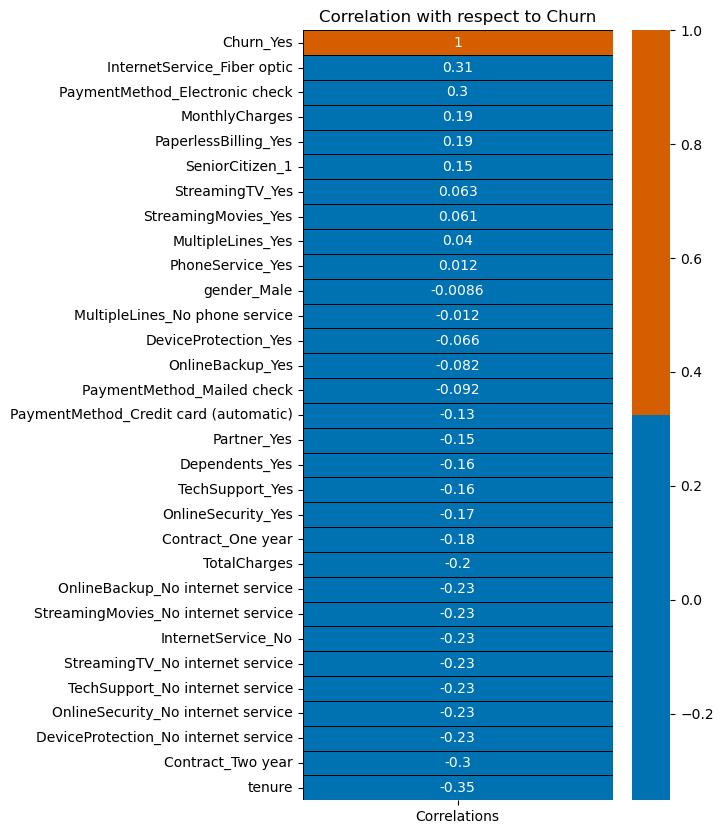

```python
# Correlation of features w.r.t the target variable "Churn_Yes"
colors = [blue, orange]
corr = data.corrwith(data['Churn_Yes']).sort_values(ascending = False).to_frame()
corr.columns = ['Correlations']
plt.subplots(figsize = (5,10))
sns.heatmap(corr,annot = True,cmap = colors,linewidths = 0.4,linecolor = 'black');
plt.title('Correlation with respect to Churn');
```

**Observation:** Correlation is plotted with respect to the Traget Label "Churn_Yes".

### Feature Engineering

The dataset is now converted to numeric values after the conversion of categorical features to numeric using on-hot encoding. But there is still one feature "customerID" remaining as an object data type.

This feature does not have any significance in the dataset as there are 7043 distint values for this feature. This feature uniquely identifies a single customer.

```python
#Checking the dataset

data.head()
```

|  | customerID | tenure | MonthlyCharges | TotalCharges | gender_Male | SeniorCitizen_1 | Partner_Yes | Dependents_Yes | PhoneService_Yes | MultipleLines_No phone service | ... | StreamingTV_Yes | StreamingMovies_No internet service | StreamingMovies_Yes | Contract_One year | Contract_Two year | PaperlessBilling_Yes | PaymentMethod_Credit card (automatic) | PaymentMethod_Electronic check | PaymentMethod_Mailed check | Churn_Yes |
| --- | --- | --- | --- | --- | --- | --- | --- | --- | --- | --- | --- | --- | --- | --- | --- | --- | --- | --- | --- | --- | --- |
| 0 | 7590-VHVEG | 1 | 29.85 | 29.85 | 0 | 0 | 1 | 0 | 0 | 1 | ... | 0 | 0 | 0 | 0 | 0 | 1 | 0 | 1 | 0 | 0 |
| 1 | 5575-GNVDE | 34 | 56.95 | 1889.50 | 1 | 0 | 0 | 0 | 1 | 0 | ... | 0 | 0 | 0 | 1 | 0 | 0 | 0 | 0 | 1 | 0 |
| 2 | 3668-QPYBK | 2 | 53.85 | 108.15 | 1 | 0 | 0 | 0 | 1 | 0 | ... | 0 | 0 | 0 | 0 | 0 | 1 | 0 | 0 | 1 | 1 |
| 3 | 7795-CFOCW | 45 | 42.30 | 1840.75 | 1 | 0 | 0 | 0 | 0 | 1 | ... | 0 | 0 | 0 | 1 | 0 | 0 | 0 | 0 | 0 | 0 |
| 4 | 9237-HQITU | 2 | 70.70 | 151.65 | 0 | 0 | 0 | 0 | 1 | 0 | ... | 0 | 0 | 0 | 0 | 0 | 1 | 0 | 1 | 0 | 1 |

5 rows × 32 columns

#### Drop insignificant feature

```python
# Dropping feature "customerID" from the dataset using the drop() function

data.drop(['customerID'],axis=1,inplace=True)
```

```python
# Checking dataset after dropping the feature

data.head()
```

|  | tenure | MonthlyCharges | TotalCharges | gender_Male | SeniorCitizen_1 | Partner_Yes | Dependents_Yes | PhoneService_Yes | MultipleLines_No phone service | MultipleLines_Yes | ... | StreamingTV_Yes | StreamingMovies_No internet service | StreamingMovies_Yes | Contract_One year | Contract_Two year | PaperlessBilling_Yes | PaymentMethod_Credit card (automatic) | PaymentMethod_Electronic check | PaymentMethod_Mailed check | Churn_Yes |
| --- | --- | --- | --- | --- | --- | --- | --- | --- | --- | --- | --- | --- | --- | --- | --- | --- | --- | --- | --- | --- | --- |
| 0 | 1 | 29.85 | 29.85 | 0 | 0 | 1 | 0 | 0 | 1 | 0 | ... | 0 | 0 | 0 | 0 | 0 | 1 | 0 | 1 | 0 | 0 |
| 1 | 34 | 56.95 | 1889.50 | 1 | 0 | 0 | 0 | 1 | 0 | 0 | ... | 0 | 0 | 0 | 1 | 0 | 0 | 0 | 0 | 1 | 0 |
| 2 | 2 | 53.85 | 108.15 | 1 | 0 | 0 | 0 | 1 | 0 | 0 | ... | 0 | 0 | 0 | 0 | 0 | 1 | 0 | 0 | 1 | 1 |
| 3 | 45 | 42.30 | 1840.75 | 1 | 0 | 0 | 0 | 0 | 1 | 0 | ... | 0 | 0 | 0 | 1 | 0 | 0 | 0 | 0 | 0 | 0 |
| 4 | 2 | 70.70 | 151.65 | 0 | 0 | 0 | 0 | 1 | 0 | 0 | ... | 0 | 0 | 0 | 0 | 0 | 1 | 0 | 1 | 0 | 1 |

5 rows × 31 columns

#### Rename target feature

- After one-hot encoding the target variable "Churn" was converted to "Churn_Yes".
- Renaming the new name back to "Churn"

```python
data.rename(columns = {'Churn_Yes':'Churn'}, inplace=True)
```

```python
#Checking the dataset

data.head()
```

|  | tenure | MonthlyCharges | TotalCharges | gender_Male | SeniorCitizen_1 | Partner_Yes | Dependents_Yes | PhoneService_Yes | MultipleLines_No phone service | MultipleLines_Yes | ... | StreamingTV_Yes | StreamingMovies_No internet service | StreamingMovies_Yes | Contract_One year | Contract_Two year | PaperlessBilling_Yes | PaymentMethod_Credit card (automatic) | PaymentMethod_Electronic check | PaymentMethod_Mailed check | Churn |
| --- | --- | --- | --- | --- | --- | --- | --- | --- | --- | --- | --- | --- | --- | --- | --- | --- | --- | --- | --- | --- | --- |
| 0 | 1 | 29.85 | 29.85 | 0 | 0 | 1 | 0 | 0 | 1 | 0 | ... | 0 | 0 | 0 | 0 | 0 | 1 | 0 | 1 | 0 | 0 |
| 1 | 34 | 56.95 | 1889.50 | 1 | 0 | 0 | 0 | 1 | 0 | 0 | ... | 0 | 0 | 0 | 1 | 0 | 0 | 0 | 0 | 1 | 0 |
| 2 | 2 | 53.85 | 108.15 | 1 | 0 | 0 | 0 | 1 | 0 | 0 | ... | 0 | 0 | 0 | 0 | 0 | 1 | 0 | 0 | 1 | 1 |
| 3 | 45 | 42.30 | 1840.75 | 1 | 0 | 0 | 0 | 0 | 1 | 0 | ... | 0 | 0 | 0 | 1 | 0 | 0 | 0 | 0 | 0 | 0 |
| 4 | 2 | 70.70 | 151.65 | 0 | 0 | 0 | 0 | 1 | 0 | 0 | ... | 0 | 0 | 0 | 0 | 0 | 1 | 0 | 1 | 0 | 1 |

5 rows × 31 columns

```python
#Checking the shape of the dataset

data.shape
```

```
(7043, 31)
```

#### Standardization

```python
# Create object of the class

scaler= StandardScaler()

#Separating the input features and target variable

#Dependant input features
x = data.drop('Churn', axis=1)

#Target variable
y = data['Churn']

# Standardization

scaler_object = scaler.fit_transform(x)
scale = pd.DataFrame(scaler_object,columns=x.columns)
scale.head()
```

|  | tenure | MonthlyCharges | TotalCharges | gender_Male | SeniorCitizen_1 | Partner_Yes | Dependents_Yes | PhoneService_Yes | MultipleLines_No phone service | MultipleLines_Yes | ... | StreamingTV_No internet service | StreamingTV_Yes | StreamingMovies_No internet service | StreamingMovies_Yes | Contract_One year | Contract_Two year | PaperlessBilling_Yes | PaymentMethod_Credit card (automatic) | PaymentMethod_Electronic check | PaymentMethod_Mailed check |
| --- | --- | --- | --- | --- | --- | --- | --- | --- | --- | --- | --- | --- | --- | --- | --- | --- | --- | --- | --- | --- | --- |
| 0 | -1.277445 | -1.160323 | -0.994242 | -1.009559 | -0.439916 | 1.034530 | -0.654012 | -3.054010 | 3.054010 | -0.854176 | ... | -0.525927 | -0.790132 | -0.525927 | -0.79607 | -0.514249 | -0.562975 | 0.829798 | -0.525047 | 1.406418 | -0.544807 |
| 1 | 0.066327 | -0.259629 | -0.173244 | 0.990532 | -0.439916 | -0.966622 | -0.654012 | 0.327438 | -0.327438 | -0.854176 | ... | -0.525927 | -0.790132 | -0.525927 | -0.79607 | 1.944582 | -0.562975 | -1.205113 | -0.525047 | -0.711026 | 1.835513 |
| 2 | -1.236724 | -0.362660 | -0.959674 | 0.990532 | -0.439916 | -0.966622 | -0.654012 | 0.327438 | -0.327438 | -0.854176 | ... | -0.525927 | -0.790132 | -0.525927 | -0.79607 | -0.514249 | -0.562975 | 0.829798 | -0.525047 | -0.711026 | 1.835513 |
| 3 | 0.514251 | -0.746535 | -0.194766 | 0.990532 | -0.439916 | -0.966622 | -0.654012 | -3.054010 | 3.054010 | -0.854176 | ... | -0.525927 | -0.790132 | -0.525927 | -0.79607 | 1.944582 | -0.562975 | -1.205113 | -0.525047 | -0.711026 | -0.544807 |
| 4 | -1.236724 | 0.197365 | -0.940470 | -1.009559 | -0.439916 | -0.966622 | -0.654012 | 0.327438 | -0.327438 | -0.854176 | ... | -0.525927 | -0.790132 | -0.525927 | -0.79607 | -0.514249 | -0.562975 | 0.829798 | -0.525047 | 1.406418 | -0.544807 |

5 rows × 30 columns

## Modeling and pipelines creation

### Machine Learning Models

- As we have already mentioned we will be using Supervised Machine Learning Models to our Project.
- We will compare various Supervised Machine Learning Models like Logistic Regression, Decision Tree Classifier, Random Forest Classifier, and Support Vector Machine and analyse the best model by hyperparameter tuning (using SMOTE)

#### Supervised Machine Learning

**Train and Test splits using stratify**

```python
# Split the dataset into train and test

# Using Stratify on the target variable as it is imbalanced.

x_train, x_test, y_train, y_test = train_test_split(scale,y, stratify=data['Churn'], test_size=0.2,random_state=123)
```

```python
# Checking our x_train data
x_train.head()
```

|  | tenure | MonthlyCharges | TotalCharges | gender_Male | SeniorCitizen_1 | Partner_Yes | Dependents_Yes | PhoneService_Yes | MultipleLines_No phone service | MultipleLines_Yes | ... | StreamingTV_No internet service | StreamingTV_Yes | StreamingMovies_No internet service | StreamingMovies_Yes | Contract_One year | Contract_Two year | PaperlessBilling_Yes | PaymentMethod_Credit card (automatic) | PaymentMethod_Electronic check | PaymentMethod_Mailed check |
| --- | --- | --- | --- | --- | --- | --- | --- | --- | --- | --- | --- | --- | --- | --- | --- | --- | --- | --- | --- | --- | --- |
| 1776 | 1.613701 | -1.321517 | -0.211631 | 0.990532 | 2.273159 | 1.034530 | -0.654012 | 0.327438 | -0.327438 | 1.170719 | ... | 1.901403 | -0.790132 | 1.901403 | -0.796070 | -0.514249 | 1.776278 | 0.829798 | -0.525047 | -0.711026 | -0.544807 |
| 2888 | -1.277445 | 0.207336 | -0.976075 | -1.009559 | 2.273159 | -0.966622 | 1.529024 | 0.327438 | -0.327438 | -0.854176 | ... | -0.525927 | -0.790132 | -0.525927 | -0.796070 | -0.514249 | -0.562975 | 0.829798 | -0.525047 | 1.406418 | -0.544807 |
| 1107 | 1.491540 | -1.346444 | -0.282599 | -1.009559 | -0.439916 | 1.034530 | -0.654012 | 0.327438 | -0.327438 | 1.170719 | ... | 1.901403 | -0.790132 | 1.901403 | -0.796070 | -0.514249 | 1.776278 | -1.205113 | -0.525047 | -0.711026 | -0.544807 |
| 4050 | 1.043616 | 1.134619 | 1.544642 | 0.990532 | 2.273159 | 1.034530 | -0.654012 | 0.327438 | -0.327438 | 1.170719 | ... | -0.525927 | 1.265612 | -0.525927 | 1.256171 | -0.514249 | -0.562975 | 0.829798 | -0.525047 | 1.406418 | -0.544807 |
| 3496 | -0.300156 | 0.317015 | -0.145541 | 0.990532 | -0.439916 | -0.966622 | -0.654012 | 0.327438 | -0.327438 | -0.854176 | ... | -0.525927 | -0.790132 | -0.525927 | -0.796070 | -0.514249 | -0.562975 | -1.205113 | -0.525047 | -0.711026 | -0.544807 |

5 rows × 30 columns

**Observation:**  
We have split the train and test data on 80:20 ratio.

**Train and Test splits using SMOTE (for handling imbalanced data)**

**SMOTE (Synthetic Minority Oversampling Technique):**  
SMOTE data augmentation technique is used in machine learning to address the problem of imbalanced datasets. In SMOTE we will increase the number of cases in an imbalanced dataset to make it balanced for the training of Data Models. The synthetic examples generated by SMOTE help to balance the distribution of examples across classes, thereby improving the performance of machine learning models. SMOTE is effective for datasets where the minority class examples can be easily interpolated in the feature space.

```python
# Counting the number of records for each class in train

counter = Counter(y_train)
print('Train set before',counter)

# Oversampling the train dataset using SMOTE

smt = SMOTE()
x_train_sm, y_train_sm = smt.fit_resample(x_train, y_train)


# Counting the number of records for each class in train after SMOTE

counter = Counter(y_train_sm)
print('Train set after',counter)

# Counting the number of records for each class in test

counter = Counter(y_test)
print('\n\nTest set before',counter)

# Oversampling the test dataset using SMOTE

smt = SMOTE()
x_test_sm, y_test_sm = smt.fit_resample(x_test, y_test)


# Counting the number of records for each class in test after SMOTE

counter = Counter(y_test_sm)
print('Test set after',counter)
```

```
Train set before Counter({0: 4139, 1: 1495})
Train set after Counter({0: 4139, 1: 4139})


Test set before Counter({0: 1035, 1: 374})
Test set after Counter({0: 1035, 1: 1035})
```

**Observation**: The imbalanced data for Churn vs non-churn output feature has been balanced using **SMOTE (Synthetic Minority Oversampling Technique)** Analysis. We will use this balanced dataset to train our Data Models

#### Logistic Regression:

Logistic regression is a statistical method used in machine learning for binary classification problems. It is a type of generalized linear model (GLM) that uses a logistic function to model the relationship between a set of input features and a binary output variable.

In our problem we are using logistic regression to estimate the probability of the Churn and non-churn classes with our set of input features.

##### Highlights of LR Model:

The logistic regression model is trained by minimizing a cost function, such as the binary cross-entropy loss, using an optimization algorithm such as gradient descent. During training, the model adjusts the weights to minimize the difference between the predicted probabilities and the actual labels in the training data.

Once trained, the logistic regression model can be used to make predictions on new data by computing the predicted probability of the positive class given the input features, and then using a decision threshold to assign a binary label.

```python
from sklearn.linear_model import LogisticRegression
#Create an object of the class

LogisticRegression = LogisticRegression()
```

```python
#Train the model

LRmodel = LogisticRegression.fit(x_train,y_train)
```

```python
#Prediction

#Train set
LR_y_pred_train = LRmodel.predict(x_train)

#Test set
LR_y_pred_test = LRmodel.predict(x_test)
```

```python
# Generate evaluation metrics

# Accuracy
print ("\nTrain Accuracy :", metrics.accuracy_score(y_train, LR_y_pred_train))
print ("\nTest Accuracy :", metrics.accuracy_score(y_test, LR_y_pred_test))

# Area under curve
print ("\nTrain AUC :", metrics.roc_auc_score(y_train, LR_y_pred_train))
print ("\nTest AUC :", metrics.roc_auc_score(y_test, LR_y_pred_test))

# Confusion matrix of test
print ("\nConfusion matrix :\n\n",metrics.confusion_matrix(y_test,LR_y_pred_test))

# Classification report of test
print ("\nclassification report :\n\n\n", metrics.classification_report(y_test,LR_y_pred_test))
```

```
Train Accuracy : 0.807596734114306

Test Accuracy : 0.7970191625266146

Train AUC : 0.7282577586074546

Test AUC : 0.7098581725180191

Confusion matrix :

 [[927 108]
 [178 196]]

classification report :


               precision    recall  f1-score   support

           0       0.84      0.90      0.87      1035
           1       0.64      0.52      0.58       374

    accuracy                           0.80      1409
   macro avg       0.74      0.71      0.72      1409
weighted avg       0.79      0.80      0.79      1409
```

**Observation:**

- Based on these metrics, we can see that the model has a **higher accuracy** on the **training set (0.807)** than on the **test set (0.797)**, indicating **some degree of overfitting.**
- The **AUC scores** are also **higher** on the **training set (0.728)** than on the **test set (0.709)**, further suggesting **overfitting**.
- The **confusion matrix** shows that the model is **better** at predicting the **negative class (0)** than the positive class (1), with more false negatives than false positives.
- The **classification report** confirms that the model has a **higher precision and recall** for the **negative class (0)** than the positive class (1).  
  Overall, the model's performance could be improved by addressing the issue of overfitting.

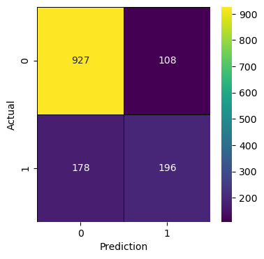

```python
# Confusion Matrix visualization

LR_confusion_matrix = metrics.confusion_matrix(y_test,LR_y_pred_test)


f, ax = plt.subplots(figsize=(4,4))
sns.heatmap(LR_confusion_matrix,annot = True, linewidths=0.5,linecolor="black",fmt=".0f",ax=ax,cmap='viridis')
plt.xlabel("Prediction")
plt.ylabel("Actual")
plt.show()
```

**Observation:**  
The **confusion matrix** shows that the model is **better** at predicting the **negative class (0)** than the positive class (1), with more false negatives than false positives.

#### Logistic Regression cross-validation

```python
# Selecting the folds of the dataset

LR_kfold = StratifiedKFold(n_splits=5)

# Use cross-validation to evaluate the model
LR_scores = cross_val_score(LRmodel, x_train, y_train, cv=LR_kfold)

# Accuracy scores for each fold
print("\nAccuracy scores:", LR_scores)

# Print the mean accuracy and standard deviation of the model
print("\nMean accuracy:", LR_scores.mean())
print("\nStandard deviation:", LR_scores.std())
```

```
Accuracy scores: [0.79414374 0.8065661  0.79325643 0.79591837 0.8268206 ]

Mean accuracy: 0.8033410506839231

Standard deviation: 0.012673409773868865
```

#### Logistic Regression (Using SMOTE)

```python
from sklearn.linear_model import LogisticRegression
#Create an object of the class

LogisticRegression_sm = LogisticRegression()

#Train the model

LRmodel_sm = LogisticRegression_sm.fit(x_train_sm,y_train_sm)

#Prediction

#Train set
LR_y_pred_train_sm = LRmodel_sm.predict(x_train_sm)

#Test set
LR_y_pred_test_sm = LRmodel_sm.predict(x_test_sm)

# generate evaluation metrics

#Accuracy
print ("\nTrain Accuracy after SMOTE :", metrics.accuracy_score(y_train_sm, LR_y_pred_train_sm))
print ("\nTest Accuracy after SMOTE:", metrics.accuracy_score(y_test_sm, LR_y_pred_test_sm))

#Area under curve
print ("\nTrain AUC after SMOTE:", metrics.roc_auc_score(y_train_sm, LR_y_pred_train_sm))
print ("\nTest AUC after SMOTE:", metrics.roc_auc_score(y_test_sm, LR_y_pred_test_sm))

#Confusion matrix of test
print ("\nConfusion matrix after SMOTE:\n\n",metrics.confusion_matrix(y_test_sm,LR_y_pred_test_sm))

#Classification report of test
print ("\nclassification report SMOTE:\n\n\n", metrics.classification_report(y_test_sm,LR_y_pred_test_sm))
```

```
Train Accuracy after SMOTE : 0.7800193283401788

Test Accuracy after SMOTE: 0.7840579710144927

Train AUC after SMOTE: 0.7800193283401787

Test AUC after SMOTE: 0.7840579710144926

Confusion matrix after SMOTE:

 [[772 263]
 [184 851]]

classification report SMOTE:


               precision    recall  f1-score   support

           0       0.81      0.75      0.78      1035
           1       0.76      0.82      0.79      1035

    accuracy                           0.78      2070
   macro avg       0.79      0.78      0.78      2070
weighted avg       0.79      0.78      0.78      2070
```

**Observation:**

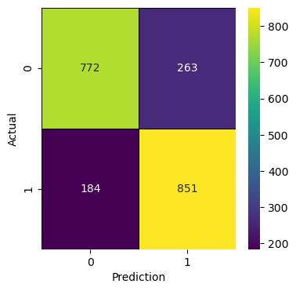

```python
# Confusion Matrix visualization

LR_confusion_matrix_sm = metrics.confusion_matrix(y_test_sm,LR_y_pred_test_sm)


f, ax = plt.subplots(figsize=(4,4))
sns.heatmap(LR_confusion_matrix_sm,annot = True, linewidths=0.5,linecolor="black",fmt=".0f",ax=ax,cmap='viridis')
plt.xlabel("Prediction")
plt.ylabel("Actual")
plt.show()
```

#### Logistic Regression cross-validation after SMOTE

```python
# Selecting the folds of the dataset

LR_kfold_sm = StratifiedKFold(n_splits=5)

# Use cross-validation to evaluate the model
LR_scores_sm = cross_val_score(LRmodel_sm, x_train_sm, y_train_sm, cv=LR_kfold)

# Accuracy scores for each fold
print("\nAccuracy scores:", LR_scores_sm)

# Print the mean accuracy and standard deviation of the model
print("\nMean accuracy:", LR_scores_sm.mean())
print("\nStandard deviation:", LR_scores_sm.std())
```

```
Accuracy scores: [0.74879227 0.77355072 0.78985507 0.78429003 0.79214502]

Mean accuracy: 0.7777266225900141

Standard deviation: 0.01582847125557803
```

#### Decision Tree Classification

Decision Tree Classification is a machine learning algorithm that builds a tree-like model for making decisions based on a set of rules learned from the data. The algorithm recursively splits the data into subsets based on the values of input features until it reaches a point where all the instances in a subset belong to the same class. The algorithm splits the data based on the feature that provides the best information gain

```python
from sklearn.tree import DecisionTreeClassifier
# Create an object of the class

DecisionTreeClassifier = DecisionTreeClassifier(max_depth=5, max_features=10, random_state=123)
```

```python
# Train your model

DTmodel = DecisionTreeClassifier.fit(x_train,y_train)
```

```python
#Prediction

#Train set
DT_y_pred_train = DTmodel.predict(x_train)

#Test set
DT_y_pred_test = DTmodel.predict(x_test)
```

```python
# Generate evaluation metrics

# Accuracy
print ("\nTrain Accuracy :", metrics.accuracy_score(y_train, DT_y_pred_train))
print ("\nTest Accuracy :", metrics.accuracy_score(y_test, DT_y_pred_test))

# Area under curve
print ("\nTrain AUC :", metrics.roc_auc_score(y_train, DT_y_pred_train))
print ("\nTest AUC :", metrics.roc_auc_score(y_test, DT_y_pred_test))

# Confusion matrix of test
print ("\nConfusion matrix :\n\n",metrics.confusion_matrix(y_test,DT_y_pred_test))

# Classification report of test
print ("\nclassification report :\n\n\n", metrics.classification_report(y_test,DT_y_pred_test))
```

```
Train Accuracy : 0.7974795882144124

Test Accuracy : 0.7998580553584103

Train AUC : 0.6968027434607265

Test AUC : 0.6989834405435429

Confusion matrix :

 [[946  89]
 [193 181]]

classification report :


               precision    recall  f1-score   support

           0       0.83      0.91      0.87      1035
           1       0.67      0.48      0.56       374

    accuracy                           0.80      1409
   macro avg       0.75      0.70      0.72      1409
weighted avg       0.79      0.80      0.79      1409
```

**Observation:**

- Based on the information you provided, it seems that you have trained a Decision Tree Classifier model before applying SMOTE to balance the class distribution.
- The training accuracy of the model is 0.7975, while the testing accuracy is 0.7999.
- The AUC score is 0.6968 for the training set and 0.6990 for the testing set, which suggests that the model is performing slightly better than random chance.
- The confusion matrix shows that the model correctly predicted 946 instances of class 0 and 181 instances of class 1, while incorrectly predicting 89 instances of class 0 and 193 instances of class 1.
- The classification report shows that the model has a higher precision and recall for class 0 compared to class 1, which suggests that the model is biased towards predicting class 0.  
  Overall, the model seems to be performing moderately well, but the class imbalance may be affecting its performance. It's important to consider using techniques like SMOTE to improve the model's performance on the minority class.

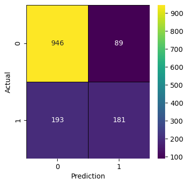

```python
# Confusion Matrix visualization

DT_confusion_matrix = metrics.confusion_matrix(y_test,DT_y_pred_test)


f, ax = plt.subplots(figsize=(4,4))
sns.heatmap(DT_confusion_matrix,annot = True, linewidths=0.5,linecolor="black",fmt=".0f",ax=ax,cmap='viridis')
plt.xlabel("Prediction")
plt.ylabel("Actual")
plt.show()
```

**Observation:**  
The confusion matrix shows that the model correctly predicted 946 instances of class 0 and 181 instances of class 1, while incorrectly predicting 89 instances of class 0 and 193 instances of class 1.

#### Decision Tree Classification cross-validation

```python
# Selecting the folds of the dataset

DT_kfold = StratifiedKFold(n_splits=5)

# Use cross-validation to evaluate the model
DT_scores = cross_val_score(DTmodel, x_train, y_train, cv=DT_kfold)

# Accuracy scores for each fold
print("\nAccuracy scores:", DT_scores)

# Print the mean accuracy and standard deviation of the model
print("\nMean accuracy:", DT_scores.mean())
print("\nStandard deviation:", DT_scores.std())
```

```
Accuracy scores: [0.78438332 0.79325643 0.78793256 0.78349601 0.80728242]

Mean accuracy: 0.7912701477223834

Standard deviation: 0.00871026055018372
```

**Observation:**

- The accuracy scores of the model on each fold of the cross-validation are [0.78438332, 0.79325643, 0.78793256, 0.78349601, 0.80728242].
- The mean accuracy score of the model across all folds is 0.7913, which indicates that the model is performing reasonably well on average.
- The standard deviation of the accuracy scores is 0.0087, which is relatively low. This suggests that the model's performance is consistent across the different folds of the cross-validation.  
  Overall, it seems that the Decision Tree model without SMOTE is also performing well but it's important to also consider other metrics and limitations of the model.

#### Decision Tree Classification (Using SMOTE)

```python
from sklearn.tree import DecisionTreeClassifier
# Create an object of the class

DecisionTreeClassifier_sm = DecisionTreeClassifier(max_depth=5, max_features=10, random_state=123)

# Train your model

DTmodel_sm = DecisionTreeClassifier_sm.fit(x_train_sm,y_train_sm)

#Prediction

#Train set
DT_y_pred_train_sm = DTmodel_sm.predict(x_train_sm)

#Test set
DT_y_pred_test_sm = DTmodel_sm.predict(x_test_sm)

# generate evaluation metrics

#Accuracy
print ("\nTrain Accuracy after SMOTE:", metrics.accuracy_score(y_train_sm, DT_y_pred_train_sm))
print ("\nTest Accuracy after SMOTE:", metrics.accuracy_score(y_test_sm, DT_y_pred_test_sm))

#Area under curve
print ("\nTrain AUC after SMOTE:", metrics.roc_auc_score(y_train_sm, DT_y_pred_train_sm))
print ("\nTest AUC after SMOTE:", metrics.roc_auc_score(y_test_sm, DT_y_pred_test_sm))

#Confusion matrix of test
print ("\nConfusion matrix after SMOTE:\n\n",metrics.confusion_matrix(y_test_sm,DT_y_pred_test_sm))

#Classification report of test
print ("\nclassification report after SMOTE:\n\n\n", metrics.classification_report(y_test_sm,DT_y_pred_test_sm))
```

```
Train Accuracy after SMOTE: 0.7757912539260691

Test Accuracy after SMOTE: 0.7777777777777778

Train AUC after SMOTE: 0.7757912539260692

Test AUC after SMOTE: 0.7777777777777778

Confusion matrix after SMOTE:

 [[798 237]
 [223 812]]

classification report after SMOTE:


               precision    recall  f1-score   support

           0       0.78      0.77      0.78      1035
           1       0.77      0.78      0.78      1035

    accuracy                           0.78      2070
   macro avg       0.78      0.78      0.78      2070
weighted avg       0.78      0.78      0.78      2070
```

**Observation:**

- The training accuracy of the model is 0.7757, while the testing accuracy is 0.7777.
- The AUC score is 0.7757 for the training set and 0.7777 for the testing set, which suggests that the model is performing slightly better than random chance.
- The confusion matrix shows that the model correctly predicted 798 instances of class 0 and 812 instances of class 1, while incorrectly predicting 237 instances of class 0 and 223 instances of class 1.
- The classification report shows that the model has similar precision and recall for both classes, which suggests that the model is now better at predicting the minority class after applying SMOTE.  
  Overall, the model seems to be performing better after applying SMOTE, as it is now better at predicting the minority class. However, it's important to consider other metrics and limitations of the model, and to explore other techniques.

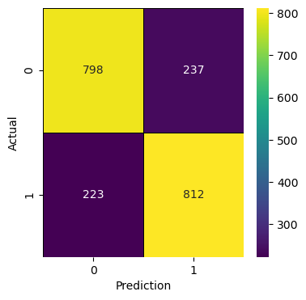

```python
# Confusion Matrix visualization

DT_confusion_matrix_sm = metrics.confusion_matrix(y_test_sm,DT_y_pred_test_sm)


f, ax = plt.subplots(figsize=(4,4))
sns.heatmap(DT_confusion_matrix_sm,annot = True, linewidths=0.5,linecolor="black",fmt=".0f",ax=ax,cmap='viridis')
plt.xlabel("Prediction")
plt.ylabel("Actual")
plt.show()
```

**Observation:**

#### Decision Tree Classification cross-validation after SMOTE

```python
# Selecting the folds of the dataset

DT_kfold_sm = StratifiedKFold(n_splits=5)

# Use cross-validation to evaluate the model
DT_scores_sm = cross_val_score(DTmodel_sm, x_train_sm, y_train_sm, cv=DT_kfold_sm)

# Accuracy scores for each fold
print("\nAccuracy scores:", DT_scores_sm)

# Print the mean accuracy and standard deviation of the model
print("\nMean accuracy:", DT_scores_sm.mean())
print("\nStandard deviation:", DT_scores_sm.std())
```

```
Accuracy scores: [0.73913043 0.75422705 0.76570048 0.77401813 0.79154079]

Mean accuracy: 0.7649233766802399

Standard deviation: 0.01772846308583012
```

**Observation:**

- The cross-validation score after using SMOTE indicates that the Decision Tree Model is performing reasonably well on the dataset.
- The mean accuracy score is slightly lower than the mean accuracy score before using SMOTE, indicating that the model may be slightly overfitting to the data.
- However, the standard deviation of the accuracy scores is relatively small, indicating that the model is generalizing well to new data.

#### Random Forrest Classification

Random Forest Classification is a supervised learning algorithm used for classification tasks. It is an ensemble learning algorithm that creates multiple decision trees and combines their outputs to make the final prediction. Random Forest overcomes the overfitting problem by randomly selecting a subset of features and a subset of data to train each decision tree.

```python
from sklearn.ensemble import RandomForestClassifier
# create an object of the class

RandomForestClassifier = RandomForestClassifier(random_state=123)
```

```python
# Train your model

RFmodel = RandomForestClassifier.fit(x_train,y_train)
```

```python
#Prediction

#Train set
RF_y_pred_train = RFmodel.predict(x_train)

#Test set
RF_y_pred_test = RFmodel.predict(x_test)
```

```python
# generate evaluation metrics

#Accuracy
print ("\nTrain Accuracy :", metrics.accuracy_score(y_train, RF_y_pred_train))
print ("\nTest Accuracy :", metrics.accuracy_score(y_test, RF_y_pred_test))

#Area under curve
print ("\nTrain AUC :", metrics.roc_auc_score(y_train, RF_y_pred_train))
print ("\nTest AUC :", metrics.roc_auc_score(y_test, RF_y_pred_test))

#Confusion matrix of test
print ("\nConfusion matrix :\n\n",metrics.confusion_matrix(y_test,RF_y_pred_test))

#Classification report of test
print ("\nclassification report :\n\n\n", metrics.classification_report(y_test,RF_y_pred_test))
```

```
Train Accuracy : 0.997515086971956

Test Accuracy : 0.8005677785663591

Train AUC : 0.9963859559245969

Test AUC : 0.7045893719806763

Confusion matrix :

 [[941  94]
 [187 187]]

classification report :


               precision    recall  f1-score   support

           0       0.83      0.91      0.87      1035
           1       0.67      0.50      0.57       374

    accuracy                           0.80      1409
   macro avg       0.75      0.70      0.72      1409
weighted avg       0.79      0.80      0.79      1409
```

**Observations:**

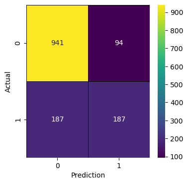

```python
# Confusion Matrix visualization

RF_confusion_matrix = metrics.confusion_matrix(y_test,RF_y_pred_test)


f, ax = plt.subplots(figsize=(4,4))
sns.heatmap(RF_confusion_matrix,annot = True, linewidths=0.5,linecolor="black",fmt=".0f",ax=ax,cmap='viridis')
plt.xlabel("Prediction")
plt.ylabel("Actual")
plt.show()
```

**Observation:**  
The model correctly identified a large number of true negatives (941) but did not perform as well in identifying true positives (187).

#### Random Forrest Classification cross-validation

```python
# Selecting the folds of the dataset

RF_kfold = StratifiedKFold(n_splits=5)

# Use cross-validation to evaluate the model
RF_scores = cross_val_score(RFmodel, x_train, y_train, cv=RF_kfold)

# Accuracy scores for each fold
print("\nAccuracy scores:", RF_scores)

# Print the mean accuracy and standard deviation of the model
print("\nMean accuracy:", RF_scores.mean())
print("\nStandard deviation:", RF_scores.std())
```

```
Accuracy scores: [0.78349601 0.7826087  0.78704525 0.79414374 0.81882771]

Mean accuracy: 0.7932242817584212

Standard deviation: 0.013430497213779848
```

**Observations:**  
Comparing the performance metrics of the Decision Tree and Random Forest models, it can be observed that the Random Forest model performs better in terms of accuracy, AUC, precision, and recall on the test set.

#### Random Forrest Classification (Using SMOTE)

```python
from sklearn.ensemble import RandomForestClassifier
# create an object of the class

RandomForestClassifier_sm = RandomForestClassifier()

# Train your model

RFmodel_sm = RandomForestClassifier_sm.fit(x_train_sm,y_train_sm)

#Prediction

#Train set
RF_y_pred_train_sm = RFmodel_sm.predict(x_train_sm)

#Test set
RF_y_pred_test_sm = RFmodel_sm.predict(x_test_sm)

# generate evaluation metrics

#Accuracy
print ("\nTrain Accuracy after SMOTE:", metrics.accuracy_score(y_train_sm, RF_y_pred_train_sm))
print ("\nTest Accuracy after SMOTE:", metrics.accuracy_score(y_test_sm, RF_y_pred_test_sm))

#Area under curve
print ("\nTrain AUC after SMOTE:", metrics.roc_auc_score(y_train_sm, RF_y_pred_train_sm))
print ("\nTest AUC after SMOTE:", metrics.roc_auc_score(y_test_sm, RF_y_pred_test_sm))

#Confusion matrix of test
print ("\nConfusion matrix after SMOTE:\n\n",metrics.confusion_matrix(y_test_sm,RF_y_pred_test_sm))

#Classification report of test
print ("\nclassification report after SMOTE:\n\n\n", metrics.classification_report(y_test_sm,RF_y_pred_test_sm))
```

```
Train Accuracy after SMOTE: 0.9981879681082387

Test Accuracy after SMOTE: 0.8072463768115942

Train AUC after SMOTE: 0.9981879681082386

Test AUC after SMOTE: 0.8072463768115943

Confusion matrix after SMOTE:

 [[883 152]
 [247 788]]

classification report after SMOTE:


               precision    recall  f1-score   support

           0       0.78      0.85      0.82      1035
           1       0.84      0.76      0.80      1035

    accuracy                           0.81      2070
   macro avg       0.81      0.81      0.81      2070
weighted avg       0.81      0.81      0.81      2070
```

**Observations:**

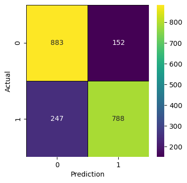

```python
# Confusion Matrix visualization

RF_confusion_matrix_sm = metrics.confusion_matrix(y_test_sm,RF_y_pred_test_sm)


f, ax = plt.subplots(figsize=(4,4))
sns.heatmap(RF_confusion_matrix_sm,annot = True, linewidths=0.5,linecolor="black",fmt=".0f",ax=ax,cmap='viridis')
plt.xlabel("Prediction")
plt.ylabel("Actual")
plt.show()
```

#### Random Forrest Classification cross-validation after SMOTE

```python
# Selecting the folds of the dataset

RF_kfold_sm = StratifiedKFold(n_splits=5)

# Use cross-validation to evaluate the model
RF_scores_sm = cross_val_score(RFmodel_sm, x_train_sm, y_train_sm, cv=RF_kfold_sm)

# Accuracy scores for each fold
print("\nAccuracy scores:", RF_scores_sm)

# Print the mean accuracy and standard deviation of the model
print("\nMean accuracy:", RF_scores_sm.mean())
print("\nStandard deviation:", RF_scores_sm.std())
```

```
Accuracy scores: [0.77415459 0.80736715 0.90157005 0.90271903 0.91722054]

Mean accuracy: 0.8606062728957777

Standard deviation: 0.05824944457521924
```

**Observation:**

#### Support Vector Machine

A Support Vector Machine (SVM) is a supervised learning algorithm used for classification problems. SVMs are used for binary classification problems, that is, when the target variable is binary (1/0, True/False, Yes/No).  
The algorithm separates the data into classes by finding the optimal hyperplane that maximizes the margin between the two classes. The margin is the distance between the hyperplane and the closest data points from each class. The SVM algorithm seeks to find the hyperplane that has the maximum margin between the two classes while minimizing the classification error.

SVM is a powerful algorithm that can handle complex data and is widely used in various fields.

```python
from sklearn.svm import SVC
# create an object of the class

SupportVectorClassifier = SVC(probability=True, random_state=123)
```

```python
# Train your model

SVCmodel = SupportVectorClassifier.fit(x_train,y_train)
```

```python
#Prediction

#Train set
SVC_y_pred_train = SVCmodel.predict(x_train)

#Test set
SVC_y_pred_test = SVCmodel.predict(x_test)
```

```python
# generate evaluation metrics

#Accuracy
print ("\nTrain Accuracy :", metrics.accuracy_score(y_train, SVC_y_pred_train))
print ("\nTest Accuracy :", metrics.accuracy_score(y_test, SVC_y_pred_test))

#Area under curve
print ("\nTrain AUC :", metrics.roc_auc_score(y_train, SVC_y_pred_train))
print ("\nTest AUC :", metrics.roc_auc_score(y_test, SVC_y_pred_test))

#Confusion matrix of test
print ("\nConfusion matrix :\n\n",metrics.confusion_matrix(y_test,SVC_y_pred_test))

#Classification report of test
print ("\nclassification report :\n\n\n", metrics.classification_report(y_test,SVC_y_pred_test))
```

```
Train Accuracy : 0.8182463613773517

Test Accuracy : 0.7934705464868701

Train AUC : 0.7290965051419689

Test AUC : 0.6946356144565862

Confusion matrix :

 [[937  98]
 [193 181]]

classification report :


               precision    recall  f1-score   support

           0       0.83      0.91      0.87      1035
           1       0.65      0.48      0.55       374

    accuracy                           0.79      1409
   macro avg       0.74      0.69      0.71      1409
weighted avg       0.78      0.79      0.78      1409
```

**Observations:**

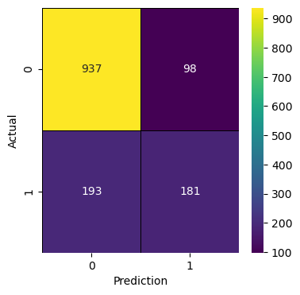

```python
# Confusion Matrix visualization

SVC_confusion_matrix = metrics.confusion_matrix(y_test,SVC_y_pred_test)


f, ax = plt.subplots(figsize=(4,4))
sns.heatmap(SVC_confusion_matrix,annot = True, linewidths=0.5,linecolor="black",fmt=".0f",ax=ax,cmap='viridis')
plt.xlabel("Prediction")
plt.ylabel("Actual")
plt.show()
```

**Observation:**

#### Support Vector Machine cross-validation

```python
# Selecting the folds of the dataset

SVC_kfold = StratifiedKFold(n_splits=5)

# Use cross-validation to evaluate the model
SVC_scores = cross_val_score(SVCmodel, x_train, y_train, cv=SVC_kfold)

# Accuracy scores for each fold
print("\nAccuracy scores:", SVC_scores)

# Print the mean accuracy and standard deviation of the model
print("\nMean accuracy:", SVC_scores.mean())
print("\nStandard deviation:", SVC_scores.std())
```

```
Accuracy scores: [0.78527063 0.80301686 0.79591837 0.79680568 0.81083481]

Mean accuracy: 0.7983692697095827

Standard deviation: 0.008450041051175718
```

**Observations:**

- The cross-validation score for the SVM model indicates that the model has an average accuracy of around 79.8%, with a standard deviation of 0.8%.
- This suggests that the model is performing consistently across the different folds, and is not overfitting to the training data.
- However, it is worth noting that the accuracy of the SVM model is lower than that of the random forest model after SMOTE.

#### Support Vector Machine (Using SMOTE)

```python
from sklearn.svm import SVC
# create an object of the class

SupportVectorClassifier_sm = SVC(probability=True, random_state=123)

# Train your model

SVCmodel_sm = SupportVectorClassifier_sm.fit(x_train_sm,y_train_sm)

#Prediction

#Train set
SVC_y_pred_train_sm = SVCmodel_sm.predict(x_train_sm)

#Test set
SVC_y_pred_test_sm = SVCmodel_sm.predict(x_test_sm)

# generate evaluation metrics

#Accuracy
print ("\nTrain Accuracy after SMOTE:", metrics.accuracy_score(y_train_sm, SVC_y_pred_train_sm))
print ("\nTest Accuracy after SMOTE:", metrics.accuracy_score(y_test_sm, SVC_y_pred_test_sm))

#Area under curve
print ("\nTrain AUC after SMOTE:", metrics.roc_auc_score(y_train_sm, SVC_y_pred_train_sm))
print ("\nTest AUC after SMOTE:", metrics.roc_auc_score(y_test_sm, SVC_y_pred_test_sm))

#Confusion matrix of test
print ("\nConfusion matrix after SMOTE:\n\n",metrics.confusion_matrix(y_test_sm,SVC_y_pred_test_sm))

#Classification report of test
print ("\nclassification report after SMOTE:\n\n\n", metrics.classification_report(y_test_sm,SVC_y_pred_test_sm))
```

```
Train Accuracy after SMOTE: 0.8406619956511234

Test Accuracy after SMOTE: 0.7903381642512077

Train AUC after SMOTE: 0.8406619956511234

Test AUC after SMOTE: 0.7903381642512077

Confusion matrix after SMOTE:

 [[808 227]
 [207 828]]

classification report after SMOTE:


               precision    recall  f1-score   support

           0       0.80      0.78      0.79      1035
           1       0.78      0.80      0.79      1035

    accuracy                           0.79      2070
   macro avg       0.79      0.79      0.79      2070
weighted avg       0.79      0.79      0.79      2070
```

**Observations:**

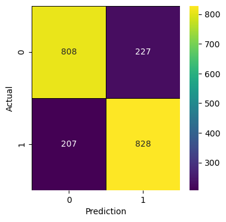

```python
# Confusion Matrix visualization

SVC_confusion_matrix_sm = metrics.confusion_matrix(y_test_sm,SVC_y_pred_test_sm)


f, ax = plt.subplots(figsize=(4,4))
sns.heatmap(SVC_confusion_matrix_sm,annot = True, linewidths=0.5,linecolor="black",fmt=".0f",ax=ax,cmap='viridis')
plt.xlabel("Prediction")
plt.ylabel("Actual")
plt.show()
```

**Observation:**

#### Support Vector Machine cross-validation after SMOTE

```python
# Selecting the folds of the dataset

SVC_kfold_sm = StratifiedKFold(n_splits=5)

# Use cross-validation to evaluate the model
SVC_scores_sm = cross_val_score(SVCmodel_sm, x_train_sm, y_train_sm, cv=SVC_kfold_sm)

# Accuracy scores for each fold
print("\nAccuracy scores:", SVC_scores_sm)

# Print the mean accuracy and standard deviation of the model
print("\nMean accuracy:", SVC_scores_sm.mean())
print("\nStandard deviation:", SVC_scores_sm.std())
```

```
Accuracy scores: [0.76751208 0.78321256 0.83272947 0.81993958 0.81993958]

Mean accuracy: 0.8046666520717485

Standard deviation: 0.024878852957787186
```

**Observation:** The mean accuracy of the SVM model after applying SMOTE and cross-validation is 0.8046 with a standard deviation of 0.024.

### Hyperparameter Tuning

- Hyperparameter tuning is the process of selecting the optimal combination of hyperparameters for a machine learning algorithm in order to maximize its performance on a given task.
- Hyperparameters are parameters that are not learned from the data but are set manually or through a search process, such as the learning rate in gradient descent or the number of trees in a random forest.
- Hyperparameter tuning is important because selecting the wrong values can lead to poor performance or even cause the model to overfit or underfit the data
- There are several methods for hyperparameter tuning, including grid search, random search, etc.
- It is an important step in building accurate and effective machine learning models.
- By selecting the right hyperparameters, we can improve the performance of our models and ensure that they are robust and generalizable.